# clustering

Ana

2025-06-06

#**ANEXO CLUSTERING**

###**Clustering de Servicios**

*Prueba de distancias*

A continuación, se muestran los resultados obtenidos con distintas métricas de distancias que fueron evaluadas pero finalmente descartadas en favor de la distancia euclídea, por ofrecer menor cohesión entre grupos o menor interpretabilidad.

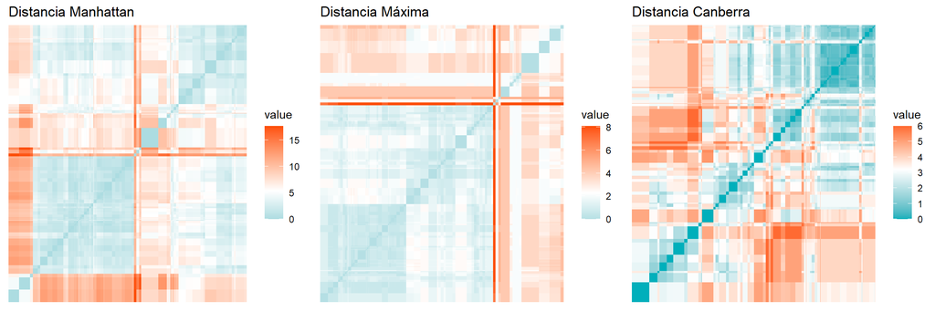

*Selección de la técnica de agrupación y del número de clusters*

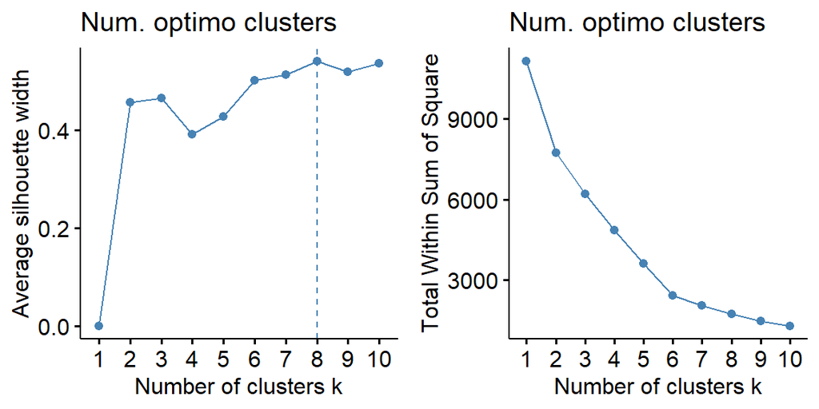

-Método de partición PAM

A través de la técnica PAM (k-medioides), obteníamos el máximo coeficiente y el mínimo SCR con 10 clusters. Sin embargo, la partición en **8 grupos** reducíamos la complejidad del análisis con índices de calidad muy similares.

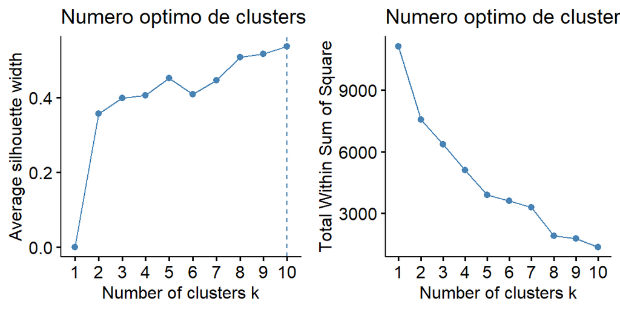

-Método de partición k-medias

Finalmente, con k-medias se maximizaba el coeficiente de Silhouette dividiendo los pisos en 3 grupos. No obstante, la SCR era todavía excesivamente elevada. La opción que mejor combinaba ambos parámetros era **k=7**.

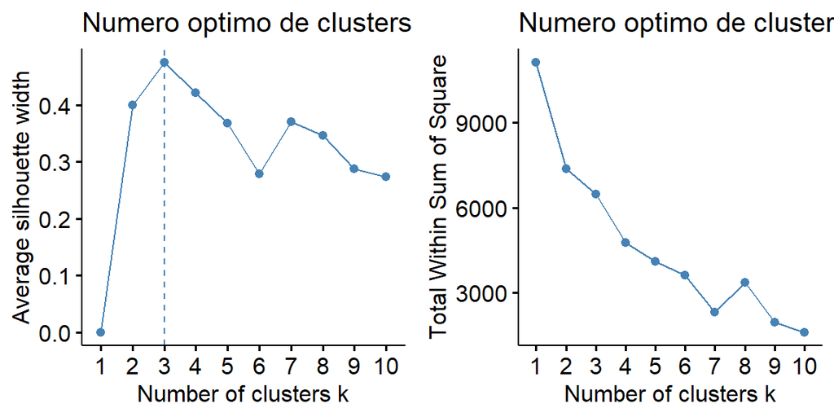

Una vez decidido el número de divisiones en cada método, comparamos los clusters resultantes. Vimos que, aunque los resultados eran similares, las **particiones de k-medias** contenían generalmente menos inmuebles mal clasificados.

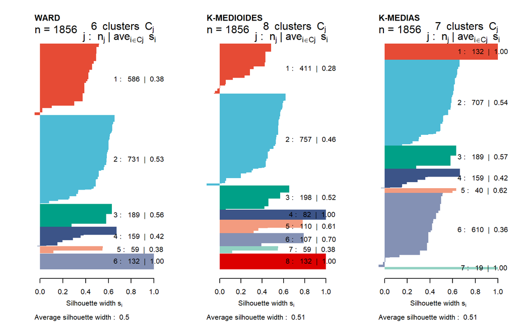

###**Clustering de Confort**

```
## # A tibble: 6 × 6
##   bathrooms rooms surface tieneAscensor tieneTrastero tieneAireAcondicionado
##       <dbl> <dbl>   <dbl>         <dbl>         <dbl>                  <dbl>
## 1         1     4     320             1             0                      1
## 2         3     3     120             0             1                      1
## 3         1     1      44             0             1                      1
## 4         3     3     135             1             0                      1
## 5         1     3      65             1             0                      1
## 6         2     4     200             1             0                      1
```

*Distancias y selección del método de agrupación* Dado que el conjunto que describe las comodidades ofrecidas por cada piso contiene tanto variables categóricas como numéricas, únicamente podíamos consultar las tendencias de agrupamiento con la distancia de Gower.

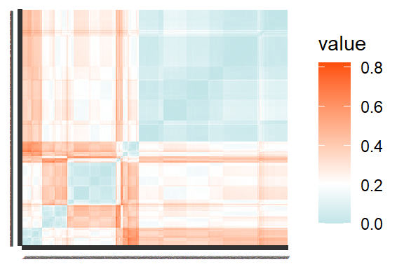

En el mapa de calor encontramos evidencias de la existencia de subgrupos en el conjunto de datos. Con el objetivo de detectar dichos clusters e interpretarlos, comenzamos el análisis probando las técnicas de Ward y k-medioides para determinar cuál generaba resultados más definidos. No aplicamos k-medias porque no habíamos utilizado la distancia euclídea.

- Método de WARD (k=5)

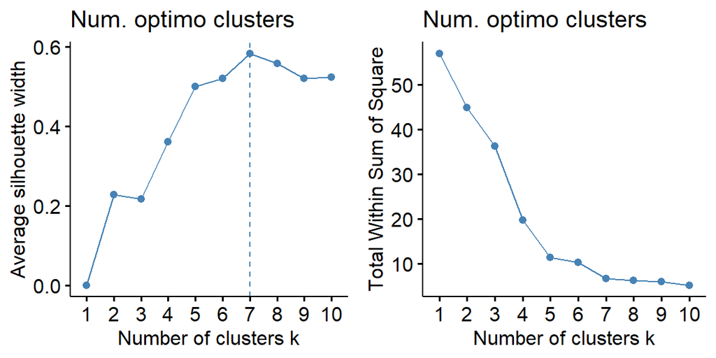

-Método PAM (k=6)

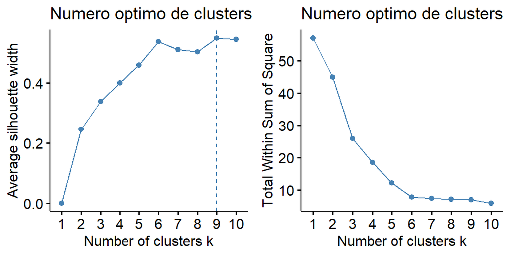

Finalmente, nos decantamos por el método *Ward* porque su coeficiente medio de Silhouette era notablemente superior.

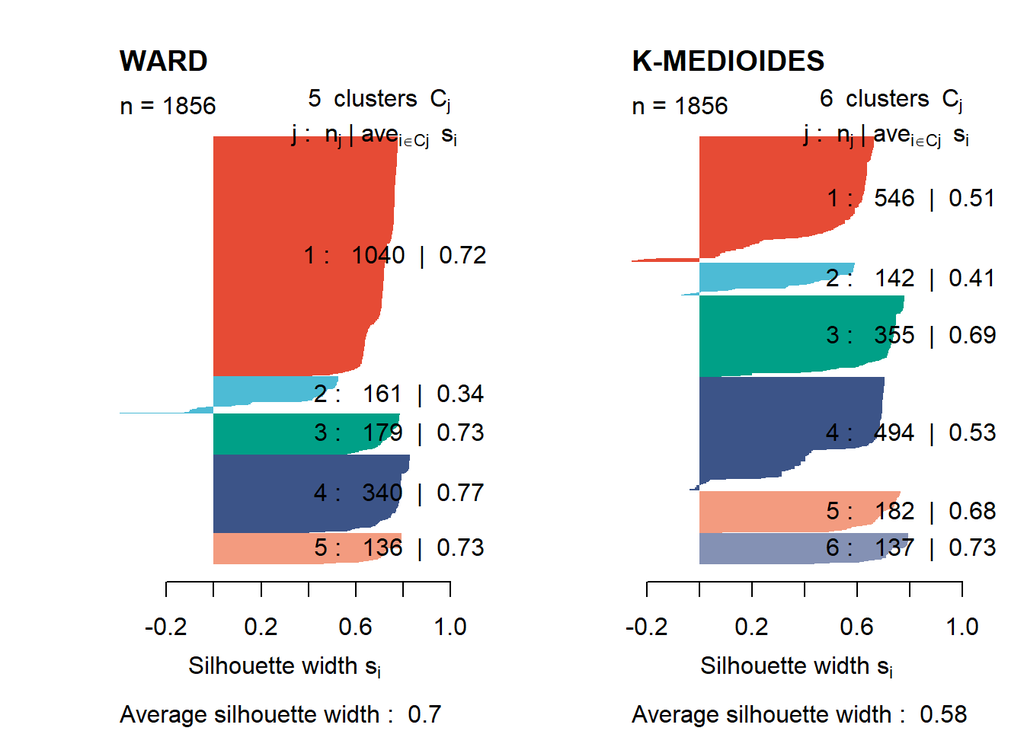

*Análisis de Componentes Principales*

Se realizó un PCA de 2 componentes (casi el 60% de la variabilidad) para comprender mejor las características de cada Cluster.

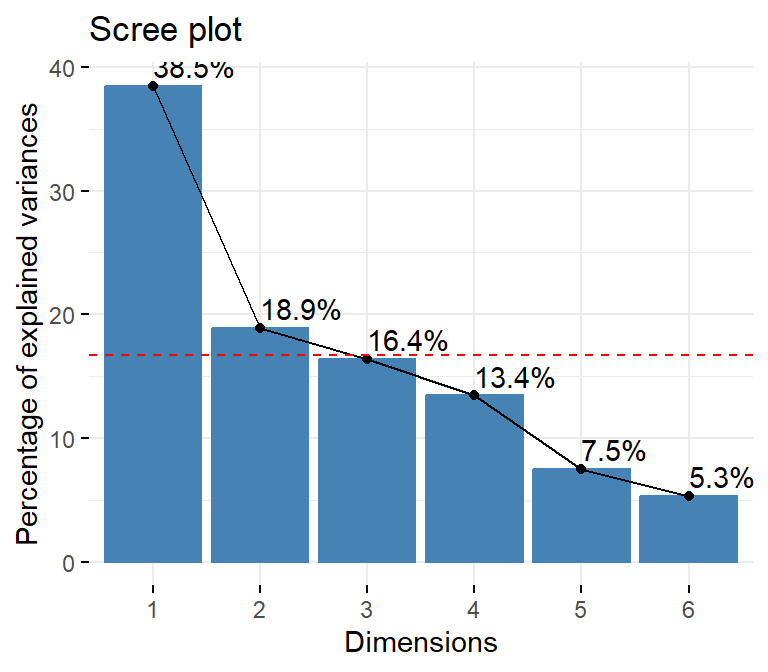

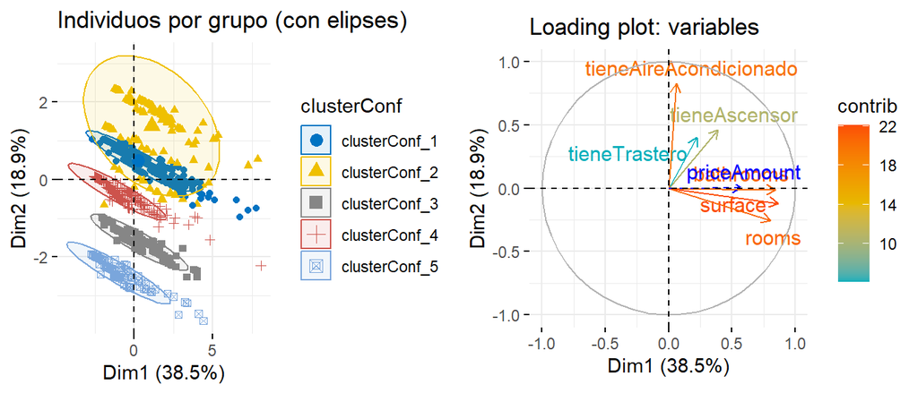

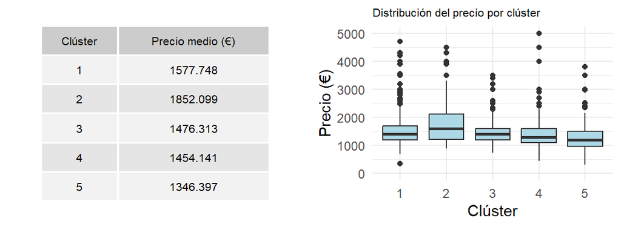

Si comparamos el precio medio de cada cluster, vemos el orden es casi idéntico a la estructura que siguen a lo largo de la segunda componente; únicamente se intercambian los clusters 3 y 4, que a su vez son los que tienen un promedio más parecido. Por lo tanto, podríamos considerar el cluster como una variable ordinal que nos indica el la categoría de cada vivienda (muy relacionada con su precio). Esta división no coincide estrictamente con el tamaño de la vivienda, sino que está más basada en sus condiciones de habitabilidad. Los niveles serían los siguientes:

Correspondencia entre nivel de calidad y clústers

| Nivel | Calidad | Clusters_originales |
| --- | --- | --- |
| 1 | Baja | 5 |
| 2 | Media | 3-4 |
| 3 | Alta | 1 |
| 4 | Lujo | 2 |

A continuación, se muestran las frecuencias de pisos en cada una de las nuevas cateorías.

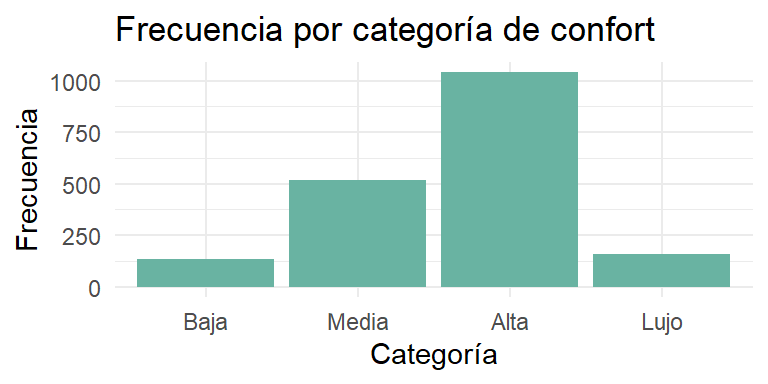